**Contacto e Informacion**  
**Telefono:** +41 41 534 96 90  
**e-mail:**info@aipel.ch

# A . I . P . E . L .

## Asociación de Inválidos y Pensionistas Españoles de Lucerna

- Nuestra Asociación en Lucerna...

  Nuestra Asociación, es una entidad sin ánimo de lucro, no gubernamental, creada a favor de la protección y la reivindicación de los derechos de los mayores y dependientes Españoles de la Suiza Central...  
  [Read Me...](http://www.aipel.ch/)
- Nuestras localidades, la sala inferior del bar...

  Esta asociación es una entidad formada por un conjunto de asociados o socios para la persecución de un fin de forma estable, sin ánimo de lucro y con una gestión democrática...  
  [Read Me...](http://www.aipel.ch/)
- Cuando el tiempo lo permite, también fuera ...

  La asociación está normalmente dotada de personalidad jurídica, por lo que desde el momento de su fundación es una persona distinta de los propios socios y es titular del patrimonio dotado originariamente por estos, del que puede disponer para perseguir los fines que se recogen en sus estatutos...  
  [Read Me...](http://www.aipel.ch/)
- Con un ambiente agradable y sencillo...

  Las asociaciones pueden realizar, además de las actividades propias de sus fines, actividades que podrían ser consideradas como empresariales, siempre y cuando el beneficio de tales actividades sea aplicado al fin principal de la entidad o, eventualmente, a otras obras sociales...  
  [Read Me...](http://www.aipel.ch/)
- Acceso adaptado a nuestra sala superior...

  La libertad de asociación o derecho de asociación es un derecho humano que consiste en la facultad de unirse y formar grupos, asociaciones u organizaciones con objetivos lícitos, así como retirarse de las mismas. La libertad o el derecho de asociación supone la libre disponibilidad de los individuos para constituir formalmente agrupaciones permanentes o personas jurídicas encaminadas a la consecución de fines específicos...  
  [Read Me...](http://www.aipel.ch/)

**Importante / Wichtig**

**Informaciones de interés sobre la Asociación:**

**1.- La reservación telefónica sigue siendo una ventaja**

**2.- A partir del 6 de junio está permitido más de 4 personas en cada mesa**

**3.- Se permiten reuniones espontáneas de hasta 30 personas**

**4.- Seguirán las medidas de prevención como hasta ahora**

**5.- Atender a las indicaciones del personal**

**Informationen über Lockerungen der Massnahmen wegen Coronavirus:**

**1.- Telefonischer Reservation ist immer noch von Vorteil**

**2.- Ab 6. Juni sind mehr als 4 Personen pro Tisch erlaub**

**3.- Versammlungsverbot wird auf 30 Personen gelockert**

**4.- Präventionsmassnahmen werden fortgesetzt**

**5.- Anweisungen des personals folgen leisten**

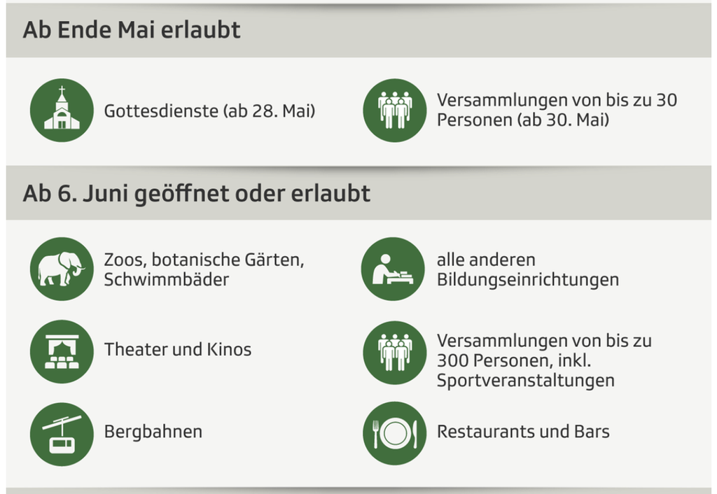

### Contacto

[figure not shown]

# A.I.P.E.L

Asociación de Inválidos y

Pensionistas Españoles

de Lucerna

Güterstrasse 20

Postfach 101

6000 Luzern 2

**Telefono:** +41 41 534 96 90

E-Mail: **info@aipel.ch**